# Unsupervised Learning : Dimensionality Reduction

## Table of Contents: Chapters

## 1. Curse of Dimensionality

## 2. Major approaches

- ### Projection
- ### Manifold learning

## 3. PCA

- ### Principal Components
- ### Projection to d-dimensions
- ### Explained variance ration
- ### Finding the right number of dimensions
- ### PCA for compression and decompression
- ### Incremental PCA
- ### Randomised PCA
- ### Kernel PCA
- ### Selecting Kernel and Hyperparameter tuning

## 4. Locally linear embedding ( LLE )

## 5. MDS, IsoMap, t-SNE, LDA

## 6. Python Workshop

- ### Complete code
- ### Projects

# Dimensionality Reduction

Many machine language problems involve thousands or even millions of features for each training instance. Not only does it make the training extremely slow, it can also make it much harder to find a good solution, as we will see. This problem is commonly referred to as the *Curse of Dimensionality.*

Fortunately it is possbile to reduce the number of features considerably, turning an intractable problem to a tractable one. For example,:

- Consider an MNIST image: the pixels on the image borders are always almost white, so we may drop those pixel points from the image training and still not lose any useful information.
- Also two neighbouring pixels are often highly correlated and so we may consider merging nearby pixels into a single pixel, and thus, again retain all the valid feature information.

Apart from speeding up training, dimensionality reduction is also extremely vital for data visualisation. By reducing the dimensionality to fewer dimensions it becomes easier to plot the data points on a graph and thus visualise useful data patterns such as clusters.

## Curse of Dimensionality

Generally it is difficult to visualise a high dimensional space. We are so over conditioned to visualise graphs of lower dimensions that we find intractable pictures of higher dimensions.

Characteristics of a problem changes with the change of dimensions. Things may tend to behave completely differently in a higher dimensional space. For example:

**However if we consider a 10,000 dimensional hyperspace, the same probability is as greater than 99.99% !!.** Most points in an higher dimensional space are close to the border than the centre.

*It can be shown that the average distance ( probabilistic average ) between any points increases as we increase the dimension. So points are sparsely disributed in a higher dimensional space as compared to a lower dimensional space.*

## Major Approaches to Dimensionality Reduction

There are two main approaches to dimensionality reduction

- Projection
- Manifold Learning

### Projection

In most real life problems, training instances are not spread out uniformly across all dimensions. Many features are almost constant while others are highly correlated. As a result, all training instances actually lie within a much lower dimensional space. Let's consider this with an example. Figure 1.1 represents a 3D dataset.

[figure not shown]

**Figure 1.1:** *A 3D dataset lying close to a 2D subspace*

Notice that all the training instances lie close to plane ( in grey color ): this is a lower 2D subspace to a higher 3D space. Now if we project every training instance perpendicularly onto this subspace, we get the new 2D dataset as shown in the Figure 1.2. With projection we have just reduced a 3D dataset to a 2D dataset. Note the new azes $z_1$ and $z_2$ now correspond to the new features in this 2D subspace.

[figure not shown]

**Figure 1.2** *New 2D dataset after projection from a 3D space*

### Drawbacks of Projection

However projection is not always the best approach. The project lower subspace may twist, turn and overlap in many cases; such as in famous *swiss roll* dataset. Figure 1.3 demonstrates a swill roll dataset.

[figure not shown]

**Figure 1.3** *Swiss roll dataset*

Simply projecting swiss roll data points to a 2D plane would overlap different regions of the swiss roll together leading to an unclear separation between the points. What we need in this situation is to simply unroll the swiss so that the variations between the regions are clearly delineated. Figure 1.4 demonstrates both the cases, squashing the swiss roll (on the left) vs unrolling the swiss (on the right ).

[figure not shown]

**Figure 1.4** *Left: Squashing the roll onto a plane, Right: unrolling the swiss roll*

This limitation is a motivation to the second approach: Manifold.

## Manifold

The swiss is an example of a 2d manifold. A 2D manifold is a 2D dimensional shape that can be bend and twisted to a higher dimensional space. To generalise, a $d$-dimensional manifold is a part of a $n$-dimensional space where $n > d$. In the case of swiss roll d = 2 and n=3. A swiss roll locally resembles a 2D space but is rolled to a higher dimensional 3D space.

### Manifold Learning

Many dimensionality reduction problems work by modeling the manifold on which the training instances lie; This is known as **Manifold Learning** .

### Manifold Assumption ( Hypothesis )

Manifold learning stems out from the *manifold assumption*:

*Most real-world high dimensional datasets lie close to a lower dimensional manifold*. *This is an empirically observed assumption.*

The manifold assumption is often accompanied by another implicit assumption, that: *The task of classification or regression is much simpler if expressed in the lower-dimensional space of the manifold*.

For example in the figure 1.5, the dataset is labelled into two distinct classes. The decision boundary on the 3D space would be faily complex but on the unrolled manifold it is much simpler. The unrolled manifold is demonstrated by Figure 1.6.

[figure not shown]

**Figure 1.5** *Complex decision boundary on 3D space*

$\\\\$

[figure not shown]

**Figure 1.6** *Decision boundary is simplied on a 2D manifold*

##### The implicit assumption is not always valid, though

This assumption that a lower dimensional manifold simplies the decision is *NOT always valid*. Figure 1.7 shows a simple decision boundary in a 3D space. But the boundary becomes complex on a lower 2D manifold as can be seen from Figure 1.8 where the data points cannot be separated by a single line.

[figure not shown]

**Figure 1.7** *Simple decision boundary on 3D space*

$\\\\$

[figure not shown]

**Figure 1.8** *Complex decision boundary on a 2D manifold*

## PCA ( Principal Component Analysis )

It is the most widely used algorithm for dimensionality reduction.

- **Firstly it identifies the hyperplane that lies closest to the dataset**
- **Then it projects the dataset onto the hyperplane.**

### Finding the right hyperplane

Before we can project the data on the hyperplane we must first find the right hyperplane. Let's demonstrate this with Figure 1.9.

[figure not shown]

**Firgure 1.9** *Projection of a 2D dataset onto 3 different hyperplanes*

#### The right hyperplane preserves the maximum variance

On the left of the figure, we represent the data on 2D plane with axes $x1$ and $x2$. We then project the data on three different hyperplanes, represented by the solid and dotted lines. You can see the distortion to the original data caused by the projection on the different hyperplanes. This projection in shown on the right side of the figure 1.9. We can clearly see the projection on the solid lines preserve the maximum variance whereas the projection on the dotted lines preserve very little variance.

Hence it is reasonable to choose a hyperplance that preserves the maximum variance thereby losing lesser information.

#### The right hyperplane also minimises the Mean Squard Distance

Another way to enumerate this would be to understand the right hyperplane as the one that minimises the *Mean Squared Distance* between the original dataset and its projection. This is the rather simple idea behind *PCA*.

### Principal Components

PCA identifies the axis that amounts for the largest amount of variance in the training set. In figure 1.9 it is the solid line. It then also identifies a second axis orthogonal to the first one that accounts for the largest amount of the remaining variance. In figure 1.9 there are two axis; for a higher dimensional data PCA would find as many axis the number of dimensions of the original dataset.

#### ith Principal component

The unit vector that defines the $i^{th}$ axis is called the $i^{th}$ principal component. In the figure 1.9 the 1st principal component ( PC ) is $c1$ whereas the second PC is the axis $c2$.

### How to find the principal components ?

#### Singular value decomposition

So how do we find the principal ccomponents ? This can be found out by a standard matrix factorisation technique known as *Singular value decomposition* . It decomposes the training matrix X into the dot products of three matrices $U. \sum . V^T$ where $v^T$ contains all the principal components we are looking for. Equation 1.1 for $V^T$ is:

$$ V^T = \begin{pmatrix} .. & .. & .. \\ .. & .. & .. \\ c_1 & c_2 & c_3 \\ .. & .. & .. \\ .. & .. & .. \end{pmatrix} $$

##### PCA assumes data is centered around origin. Scikit PCA will adjust data for you if needed. However with other libraries you must centre the data first

### PCA in brief

- PCA finds axis responsible for largest amount of variance in dataset.
- Also finds 2nd axis, responsible for next largest amount.
- If higher-D dataset, PCA also finds 3rd axis...
- Repeat for # of dimensions in the dataset.
- Each axis vector is called a **principal component**. (PC)
- PCs found using **Singular Value Decomposition (SVD)**, a matrix factorization technique.
- SVD decomposes training set matrix X into dot product of three matrices.
- Note: PCA assumes data is centered around origin. Scikit PCA will adjust data for you if needed.

#### Sample Python code to find the svd()

# use NumPy svd() to get principal components of training set, # then extract 1st two PCs. X_centered = X - X.mean(axis=0) U,s,V = np.linalg.svd(X_centered) c1, c2 = V.T[:,0], V.T[:,1] print(c1,c2)

### Projection to d dimension

Once you have identified all the principal components, you can reduce the dimensions of the dataset to $d$ dimensions by projecting it on the hyperplance defined by the $d$ principal components.

To project the training set onto the hyperplane, you can simply compute the dot product of the training set matrix $X$ by the matrix $W_d$ defined as the matrix containing the first $d$ principal components, i.e matrix composed of the first $d$ columns of $V^T$. The equation of this as below:

$$X_{d-proj}=X.W_d$$

Below python code projects the training set onto the plane defined by the first two principal components.

W2 = V.T[:, :2] X2D = X_centered.dot(W2) print(X2D)

### Using scikit-learn

- Uses SVD decomposition as before.
- You can access each PC using *components_* variable. For example, the first principal component is equal to pca.components_.T[:, 0]

from sklearn.decomposition import PCA pca = PCA(n_components = 2) X2D = pca.fit_transform(X) print(pca.components_[0]) print(pca.components_.T[:,0]) print(X2D[:3,: ])

### Explained Variance ratio

Another useful piece of information is the *Explained Variance Ratio* of each principal component. Using scikit-learn this is accessible via the *explained_variance*ratio**. It indicates the percentage of the dataset lying along each of the principal components.

For e.g:

*pca.explained_variance*ratio**

[0.95369864 0.04630136]

This tells us that 95.3% of the dataset lies along the first PC and 4.6% lies along the seond PC. The rest is the lost information and which can be assumed to have little importance.

evr = pca.explained_variance_ratio_ print(evr)

### Choosing the right number of dimensions

Instead of arbitrarily choosing the number of dimensions to reduce down to, it is generally preferred to choose the dimensions that amount of the least loss of the variance. The optimal number of dimensions of PC must account for maximum chosen variance ( i.e we may choose say, 95% or maybe even 93% as ideal variance that we want to preserve).

In case we are reducing the dimensions for data visualisation, then the the preferred reduced dimensions are either 2 or 3.

#### Below code finds minimum d to preserve 95% of training set variance

pca = PCA() pca.fit(X) cumsum = np.cumsum(pca.explained_variance_ratio_) print(cumsum) d = np.argmax(cumsum >= 0.95) + 1 print(d)

- **Another way would be set n_components a variable between $0$ and $1$, which will tell the PCA to preserve that amount of variace.**

For e.g., the below code is an alternate code to preserver 95% of the variance

pca = PCA(n_components=0.95) X_reduced = pca.fit_transform(X_train_centered)

- **Yet another option is to plot the explaind variance as a function of the number of dimensions.**

This plot would be an elbow curve which will allow us to visualise and hence choose the right dimensions.

## PCA for compression

After dimensionality reduction the training set takes much lesser space than the original dataset. For example, applying PCA to MNIST dataset and preserving 95% of the variace, the original 784 dimensions reduce to aorund 150. That's a massive reduction while still preserving all the vital information.

- This reduction in the dimensionality tremendously speeds up the classification algorithms ( such as SVM ).

### Decompression and Reconstruction error

While the PCA can compress the original dimensions to a reduced set, it is also possible to do the reverse, i.e. to decompress the reduced dimensions back to its native state. This decompression does lose some information such as 5% loss on decompression on a dataset which was reduced by preserving 95% variance. But still the decompresse data is quite close to the original dataset and can be re-used. The mean squared distance between the original dataset and the reconstructed data is called the *Reconstruction error* .

The following code compresses the MNIST dataset to 150 dimensions and then decompresses it back to 748 dimension using the *inverse_transform()* method.

Also, the equation for inverse transformation can be written as:

$$X_{recovered} = X_{d-proj}.W_d^T$$

*Below digram shows the original MNIST data( on left ) VS the Compressed data ( on the right ).* Pretty good results !!

[figure not shown]

**Figure 1.20**: *Left: Original MNIST data with 784 dimension, Right: PCA compressed data with 154 dimensions*

**Note:** *See the Python workshop ( section: Python workshop on PCA Compression and Decompression on MNIST dataset ) for the actual code implementation.*

## Incremental PCA

PCA uses the whole dataset to fit the data to SVD algorithm. However **Incremental PCA** allows the data to fit in mini-batches. This is pretty useful for large datasets.

The following code splits the MNIST dataset into 100 mini-batches and run Incremental PCA over it to reduce the dimensionality of the MNIST dataset to 154 dimensions. The only difference here is that you must call the *partial_fit()* with Incremental PCA instead of the *fit()* method.

# split MNIST into 100 minibatches using Numpy array_split() # reduce MNIST down to 154 dimensions as before. # note use of partial_fit() for each batch. from sklearn.decomposition import IncrementalPCA n_batches = 100 inc_pca = IncrementalPCA(n_components=154) for X_batch in np.array_split(X_mnist, n_batches): print(".", end="") inc_pca.partial_fit(X_batch) X_mnist_reduced_inc = inc_pca.transform(X_mnist)

## Randomised PCA

Scikit learn offers yet another variant for PCA. It is **Randomised PCA** which uses a stochastic algorithm that quickly finds an approximation to the first $d$ principal components. Its computational complexity is $\Theta {(m \space x \space d^2) }$ + $\Theta {(d^3)} $ instead of $\Theta{(m \space x \space n^2)} + \Theta{(n^3)}$ so it is much faster than the previous algorithms when $d$ is smaller than $n$. Following is the python code for it:

rnd_pca = PCA( n_components=154, random_state=42, svd_solver="randomized") X_reduced = rnd_pca.fit_transform(X_mnist)

## Kernel PCA

While using SVM classifier we have dealt with Kernel Trick that implicitly maps instances onto a higher dimensional space ( called *feature space* ), enabling non-linear classification and regression with support vector machines.

Please check our SVM and Kernel Trick Chapter

Recall that the kernel trick allows transformation of a **non-linear boundary in a lower dimensional** space to a **linear boundary in a higher dimensional space.**

The same trick can be applied to PCA as well making it possible to perform non-linear transformation for dimensionality reduction. This is known as *Kernel PCA* .

They can be pretty useful with problems such as:

- Good at preserving clusters after projection
- Unrolling datasets

$\\\\$ *Below graphs show the swiss roll reduced to 2D using kernel PCA with various kernels.*

[figure not shown]

**Figure 1.21**: *Swiss roll dimensionality reduction to a 2D using various PCA kernels*

Following is the python code that performs a kernel PCA using different kernels. ( Check the complete code with Python Workshop )

from sklearn.datasets import make_swiss_roll from sklearn.decomposition import KernelPCA X, t = make_swiss_roll( n_samples=1000, noise=0.2, random_state=42) lin_pca = KernelPCA( n_components = 2, kernel="linear", fit_inverse_transform=True) rbf_pca = KernelPCA( n_components = 2, kernel="rbf", gamma=0.0433, fit_inverse_transform=True) sig_pca = KernelPCA( n_components = 2, kernel="sigmoid", gamma=0.001, coef0=1, fit_inverse_transform=True) X_reduced_lin = lin_pca.fit_transform(X) X_reduced_rbf = rbf_pca.fit_transform(X) X_reduced_sig = sig_pca.fit_transform(X)

## Selecting a kernel and Tuning Hyperparameters

### Using GridSearchCV

*How to select the best kernel and its hyperparameters ?*

We can use grid search to select the kernel and hyperparameters that lead to the best performance of that task. For example, the following code implements this:

- Create a 2-step pipeline, first reducing dimensionality to a 2D using kPCA ( kernel PCA )
- Then apply logistic regression for classification.
- Use GridSearchCV to find the best kernel and the corresponding gamma value for kPCA.

from sklearn.model_selection import GridSearchCV from sklearn.linear_model import LogisticRegression from sklearn.pipeline import Pipeline clf = Pipeline([ ("kpca", KernelPCA(n_components=2)), ("log_reg", LogisticRegression())]) param_grid = [{ "kpca__gamma": np.linspace(0.03, 0.05, 10), "kpca__kernel": ["rbf", "sigmoid"]}] grid_search = GridSearchCV(clf, param_grid, cv=3) grid_search.fit(X, y) # best kernel & params? print(grid_search.best_params_)

The best kernel and its gamma value can thus be calculated.

### Using Minimisation of the Reconstruction error

Another approach would be to choose the kernel and the hyperparameters that yield the **lowest reconstruction error** . However reconstruction is not as easy as the linear PCA. Here's why.

##### The problem

Notice that if we could invert the linear PCA step for a given instance in the reduced space, the reconstructed point would lie in feature space and not in original space ( like the one represented by an $x$ in the diagram ). Since the feature space is infinite dimensional, we cannot compute the reconstruction point and hence we cannot compute the true reconstruction error.

##### The solution

Fortunately it is possible to find a point in the original space that would map close to the reconstructed point. This is called *Reconstruction Pre-Image* . One we have this pre-image we an measure its squared distance to its original instance.

**We an then select the kernel and its hyperparameters that minimises this reconstruction pre-image error**

##### How to perform this reconstruction ?

- Train the supervised regression model with the projected instances as the training set and the original instances as the targetd.
- Scikit-learn does this for us. All we need to do its to set *fit_inverse_transform=True*.

rbf_pca = KernelPCA( n_components = 2, kernel="rbf", gamma=0.0433, fit_inverse_transform=True) # perform reconstruction X_reduced = rbf_pca.fit_transform(X) X_preimage = rbf_pca.inverse_transform(X_reduced) # return reconstruction pre-image error from sklearn.metrics import mean_squared_error mean_squared_error(X, X_preimage)

## LLE ( Local Linear Embedding )

LLE is a powerful non-linear dimensionality reduction technique.

- It is a manifold learning technique
- Does not rely on projections like the previous algorithms

In a nutshell, it works by:

- First measures how each training instance is related to its closest neighbours ( c.n. )
- Then it looks for lower dimensional representation of the training set where these local relationships are best preserved.

##### LLE is particularly suited by unrolling twisted manifolds

The below graph is generated by unrolling a swiss roll to a 2D dataset.

[figure not shown]

**Figure 1.22**: *Unrolled swiss roll to a 2D using LLE.*

Nevertheless, LLE did a pretty good job at modeling the manifold.

Following code as LLE implementation to unroll a swiss roll to a 2D dataset. ( Complete code can be found under the python workshop ).

# Use LLE to unroll a Swiss Roll. from sklearn.manifold import LocallyLinearEmbedding X, t = make_swiss_roll( n_samples=1000, noise=0.2, random_state=41) lle = LocallyLinearEmbedding( n_neighbors=10, n_components=2, random_state=42) X_reduced = lle.fit_transform(X)

### LLE algorithm in brief

**Firstly:**

- For each instance, LLE finds k nearest neighbors & tries to reconstruct instance as linear function of neighbors (weights such that squared distance is minimum).
- Weight matrix W now encodes all local linear relations between instances.

**Secondly:**

- Map instances into d-dimensional space & preserve relationship data

## Other Dimensionality Reduction Techniques

### Multidimensional Scaling ( MDS )

This reduces the dimensionality while trying to preserve the distances between the instances.

### IsoMap

This creates a graph by:

- Connecting each instance to its nearest neighbours.
- Then reduces dimensionality by trying to preserve the *geodesic distances* between the instances

### t-Distributed Stochastic Neighbour Embedding ( t-SNE )

- Tries to keep similar distances close and dissimilar distances apart.
- Mostly used for visualisation; mostly to visualise clusters of instances in high dimensional space.

### Linear Discriminant Analysis ( LDA )

- Classification algorithm
- Learns the discriminative axes between the classes.
- These axes can then be used to define a hyperplane onto which the data can be projected.
- Good technique to reduce dimensionality before running another classification algorithm such as SVM.

[figure not shown]

**Figure 1.23**: *Reducing swiss roll to a 2D using various techniques*

### Python code implementation for MDS, IsoMap, t-SNE and LDA

from sklearn.manifold import MDS mds = MDS(n_components=2, random_state=42) X_reduced_mds = mds.fit_transform(X) from sklearn.manifold import Isomap isomap = Isomap(n_components=2) X_reduced_isomap = isomap.fit_transform(X) from sklearn.manifold import TSNE tsne = TSNE(n_components=2) X_reduced_tsne = tsne.fit_transform(X) from sklearn.discriminant_analysis import LinearDiscriminantAnalysis lda = LinearDiscriminantAnalysis(n_components=2) X_mnist = mnist["data"] y_mnist = mnist["target"] lda.fit(X_mnist, y_mnist) X_reduced_lda = lda.transform(X_mnist)

# Python Workshop

## Projection: Code to draw the figure 1.1

```python
# To plot pretty figures
%matplotlib inline
import matplotlib
import matplotlib.pyplot as plt

plt.rcParams['axes.labelsize'] = 14
plt.rcParams['xtick.labelsize'] = 12
plt.rcParams['ytick.labelsize'] = 12

# Where to save the figures
PROJECT_ROOT_DIR = "../diagrams/unsupervised"
CHAPTER_ID = "dim_reduction"

def save_fig(fig_id, tight_layout=True):
    path = os.path.join(PROJECT_ROOT_DIR, fig_id + ".png")
    print("Saving figure", fig_id)
    if tight_layout:
        plt.tight_layout()
    plt.savefig(path, format='png', dpi=50)
```

```python
import numpy as np
import numpy.random as rnd
%matplotlib inline

# Common imports
import numpy as np
import os

# to make this notebook's output stable across runs
# build a 3D dataset
rnd.seed(4)
m = 60
w1, w2 = 0.1, 0.3
noise = 0.1

angles = rnd.rand(m) * 3 * np.pi / 2 - 0.5
X = np.empty((m, 3))
X[:, 0] = np.cos(angles) + np.sin(angles)/2 + noise * rnd.randn(m) / 2
X[:, 1] = np.sin(angles) * 0.7 + noise * rnd.randn(m) / 2
X[:, 2] = X[:, 0] * w1 + X[:, 1] * w2 + noise * rnd.randn(m)

# mean-normalize the data
X = X - X.mean(axis=0)

# apply PCA to reduce to 2D
from sklearn.decomposition import PCA

pca = PCA(n_components = 2)
X2D = pca.fit_transform(X)

# recover 3D points projected on 2D plane
X2D_inv = pca.inverse_transform(X2D)
```

```python
# utility to draw 3D arrows
from matplotlib.patches import FancyArrowPatch
from mpl_toolkits.mplot3d import proj3d

class Arrow3D(FancyArrowPatch):
    def __init__(self, xs, ys, zs, *args, **kwargs):
        FancyArrowPatch.__init__(self, (0,0), (0,0), *args, **kwargs)
        self._verts3d = xs, ys, zs

    def draw(self, renderer):
        xs3d, ys3d, zs3d = self._verts3d
        xs, ys, zs = proj3d.proj_transform(xs3d, ys3d, zs3d, renderer.M)
        self.set_positions((xs[0],ys[0]),(xs[1],ys[1]))
        FancyArrowPatch.draw(self, renderer)

# express plane as function of x,y
axes = [-1.8, 1.8, -1.3, 1.3, -1.0, 1.0]

x1s = np.linspace(axes[0], axes[1], 10)
x2s = np.linspace(axes[2], axes[3], 10)
x1, x2 = np.meshgrid(x1s, x2s)

C = pca.components_
R = C.T.dot(C)
z = (R[0, 2] * x1 + R[1, 2] * x2) / (1 - R[2, 2])
```

```
Saving figure dataset_3d_plot
```

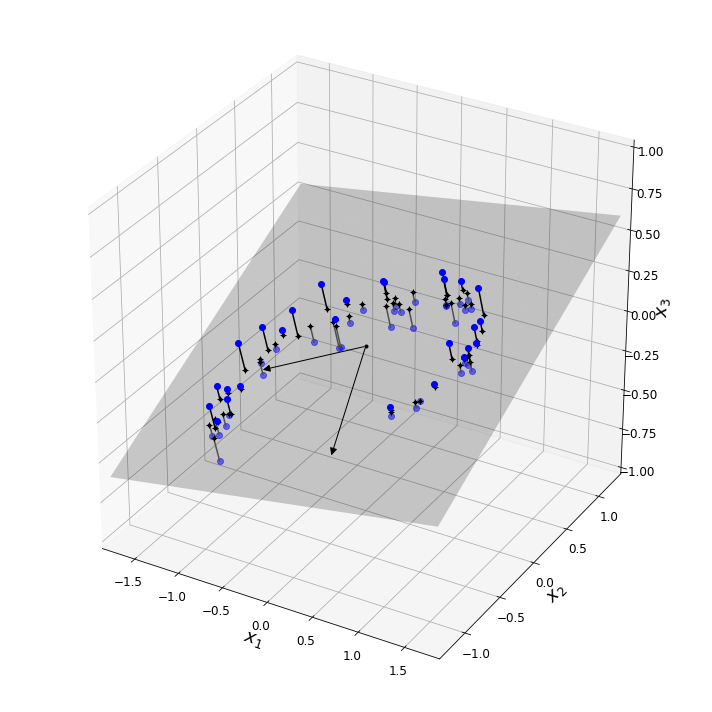

```python
# plot 3D dataset, plane & projections

import matplotlib.pyplot as plt
from mpl_toolkits.mplot3d import Axes3D

fig = plt.figure(figsize=(10, 10))
ax = fig.add_subplot(111, projection='3d')

X3D_above = X[X[:, 2] > X2D_inv[:, 2]]
X3D_below = X[X[:, 2] <= X2D_inv[:, 2]]

ax.plot(X3D_below[:, 0], X3D_below[:, 1], X3D_below[:, 2], "bo", alpha=0.5)

ax.plot_surface(x1, x2, z, alpha=0.2, color="k")
np.linalg.norm(C, axis=0)
ax.add_artist(Arrow3D([0, C[0, 0]],[0, C[0, 1]],[0, C[0, 2]], mutation_scale=15, lw=1, arrowstyle="-|>", color="k"))
ax.add_artist(Arrow3D([0, C[1, 0]],[0, C[1, 1]],[0, C[1, 2]], mutation_scale=15, lw=1, arrowstyle="-|>", color="k"))
ax.plot([0], [0], [0], "k.")

for i in range(m):
    if X[i, 2] > X2D_inv[i, 2]:
        ax.plot([X[i][0], X2D_inv[i][0]], [X[i][1], X2D_inv[i][1]], [X[i][2], X2D_inv[i][2]], "k-")
    else:
        ax.plot([X[i][0], X2D_inv[i][0]], [X[i][1], X2D_inv[i][1]], [X[i][2], X2D_inv[i][2]], "k-", color="#505050")

ax.plot(X2D_inv[:, 0], X2D_inv[:, 1], X2D_inv[:, 2], "k+")
ax.plot(X2D_inv[:, 0], X2D_inv[:, 1], X2D_inv[:, 2], "k.")
ax.plot(X3D_above[:, 0], X3D_above[:, 1], X3D_above[:, 2], "bo")
ax.set_xlabel("$x_1$", fontsize=18)
ax.set_ylabel("$x_2$", fontsize=18)
ax.set_zlabel("$x_3$", fontsize=18)
ax.set_xlim(axes[0:2])
ax.set_ylim(axes[2:4])
ax.set_zlim(axes[4:6])

save_fig("dataset_3d_plot")
plt.show()
```

### Projection : Figure 1.2

```
Saving figure 3d_to_2d_projection
```

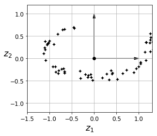

```python
# 2D projection equivalent:
fig = plt.figure()
ax = fig.add_subplot(111, aspect='equal')
ax.plot(X2D[:, 0], X2D[:, 1], "k+")
ax.plot(X2D[:, 0], X2D[:, 1], "k.")
ax.plot([0], [0], "ko")
ax.arrow(0, 0, 0, 1, head_width=0.05, length_includes_head=True, head_length=0.1, fc='k', ec='k')
ax.arrow(0, 0, 1, 0, head_width=0.05, length_includes_head=True, head_length=0.1, fc='k', ec='k')
ax.set_xlabel("$z_1$", fontsize=18)
ax.set_ylabel("$z_2$", fontsize=18, rotation=0)
ax.axis([-1.5, 1.3, -1.2, 1.2])
ax.grid(True)

save_fig("3d_to_2d_projection")

plt.show()
```

## Projection: Figure 1.3

```
Saving figure swiss_roll_plot
```

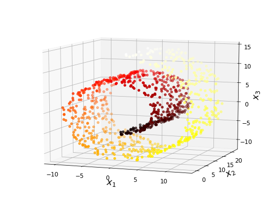

```python
# Swiss roll visualization:
from sklearn.datasets import make_swiss_roll
X, t = make_swiss_roll(n_samples=1000, noise=0.2, random_state=42)

axes = [-11.5, 14, -2, 23, -12, 15]

fig = plt.figure(figsize=(8, 6))
ax = fig.add_subplot(111, projection='3d')

ax.scatter(X[:, 0], X[:, 1], X[:, 2], c=t, cmap=plt.cm.hot)
ax.view_init(10, -70)
ax.set_xlabel("$x_1$", fontsize=18)
ax.set_ylabel("$x_2$", fontsize=18)
ax.set_zlabel("$x_3$", fontsize=18)
ax.set_xlim(axes[0:2])
ax.set_ylim(axes[2:4])
ax.set_zlim(axes[4:6])

save_fig("swiss_roll_plot")
plt.show()
```

## Projection: Figure 1.4

```
Saving figure squished_swiss_roll_plot
```

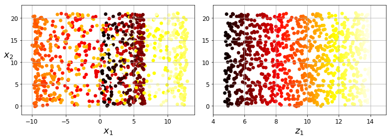

```python
# "squashed" swiss roll visualization:
plt.figure(figsize=(11, 4))

plt.subplot(121)
plt.scatter(X[:, 0], X[:, 1], c=t, cmap=plt.cm.hot)
plt.axis(axes[:4])
plt.xlabel("$x_1$", fontsize=18)
plt.ylabel("$x_2$", fontsize=18, rotation=0)
plt.grid(True)

plt.subplot(122)
plt.scatter(t, X[:, 1], c=t, cmap=plt.cm.hot)
plt.axis([4, 15, axes[2], axes[3]])
plt.xlabel("$z_1$", fontsize=18)
plt.grid(True)

save_fig("squished_swiss_roll_plot")
plt.show()
```

## Manifold:

### Figure 1.5, 1.6, 1.7, 1.8

```
Saving figure manifold_decision_boundary_plot1
```

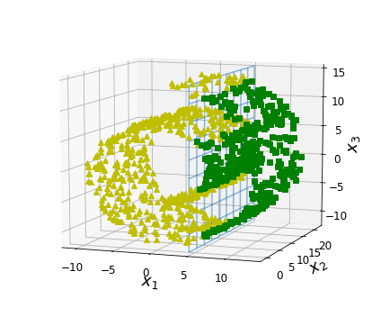

```
Saving figure manifold_decision_boundary_plot2
```

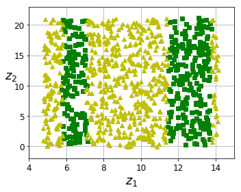

```
Saving figure manifold_decision_boundary_plot3
```

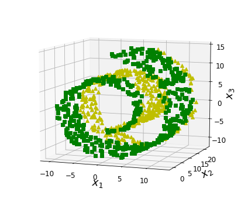

```
Saving figure manifold_decision_boundary_plot4
```

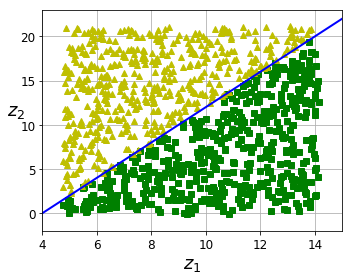

```python
from matplotlib import gridspec

axes = [-11.5, 14, -2, 23, -12, 15]

x2s = np.linspace(axes[2], axes[3], 10)
x3s = np.linspace(axes[4], axes[5], 10)
x2, x3 = np.meshgrid(x2s, x3s)

fig = plt.figure(figsize=(6, 5))
ax = plt.subplot(111, projection='3d')

positive_class = X[:, 0] > 5
X_pos = X[positive_class]
X_neg = X[~positive_class]

ax.view_init(10, -70)
ax.plot(X_neg[:, 0], X_neg[:, 1], X_neg[:, 2], "y^")
ax.plot_wireframe(5, x2, x3, alpha=0.5)
ax.plot(X_pos[:, 0], X_pos[:, 1], X_pos[:, 2], "gs")
ax.set_xlabel("$x_1$", fontsize=18)
ax.set_ylabel("$x_2$", fontsize=18)
ax.set_zlabel("$x_3$", fontsize=18)
ax.set_xlim(axes[0:2])
ax.set_ylim(axes[2:4])
ax.set_zlim(axes[4:6])

save_fig("manifold_decision_boundary_plot1")
plt.show()

fig = plt.figure(figsize=(5, 4))
ax = plt.subplot(111)

plt.plot(t[positive_class], X[positive_class, 1], "gs")
plt.plot(t[~positive_class], X[~positive_class, 1], "y^")
plt.axis([4, 15, axes[2], axes[3]])
plt.xlabel("$z_1$", fontsize=18)
plt.ylabel("$z_2$", fontsize=18, rotation=0)
plt.grid(True)

save_fig("manifold_decision_boundary_plot2")
plt.show()

fig = plt.figure(figsize=(6, 5))
ax = plt.subplot(111, projection='3d')

positive_class = 2 * (t[:] - 4) > X[:, 1]
X_pos = X[positive_class]
X_neg = X[~positive_class]
ax.view_init(10, -70)
ax.plot(X_neg[:, 0], X_neg[:, 1], X_neg[:, 2], "y^")
ax.plot(X_pos[:, 0], X_pos[:, 1], X_pos[:, 2], "gs")
ax.set_xlabel("$x_1$", fontsize=18)
ax.set_ylabel("$x_2$", fontsize=18)
ax.set_zlabel("$x_3$", fontsize=18)
ax.set_xlim(axes[0:2])
ax.set_ylim(axes[2:4])
ax.set_zlim(axes[4:6])

save_fig("manifold_decision_boundary_plot3")
plt.show()

fig = plt.figure(figsize=(5, 4))
ax = plt.subplot(111)

plt.plot(t[positive_class], X[positive_class, 1], "gs")
plt.plot(t[~positive_class], X[~positive_class, 1], "y^")
plt.plot([4, 15], [0, 22], "b-", linewidth=2)
plt.axis([4, 15, axes[2], axes[3]])
plt.xlabel("$z_1$", fontsize=18)
plt.ylabel("$z_2$", fontsize=18, rotation=0)
plt.grid(True)

save_fig("manifold_decision_boundary_plot4")
plt.show()

# Lesson learned (below):
# Unrolling a dataset to a lower dimension doesn't necessarily lead to
# a simpler representation.
```

## PCA: Figure 1.9, 1.20

```
Saving figure pca_best_projection
```

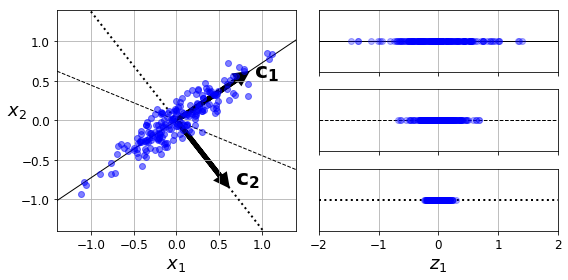

```python
angle = np.pi / 5
stretch = 5
m = 200

rnd.seed(3)
X = rnd.randn(m, 2) / 10
X = X.dot(np.array([[stretch, 0],[0, 1]])) # stretch
X = X.dot([[np.cos(angle), np.sin(angle)], [-np.sin(angle), np.cos(angle)]]) # rotate

u1 = np.array([np.cos(angle), np.sin(angle)])
u2 = np.array([np.cos(angle - 2 * np.pi/6), np.sin(angle - 2 * np.pi/6)])
u3 = np.array([np.cos(angle - np.pi/2), np.sin(angle - np.pi/2)])

X_proj1 = X.dot(u1.reshape(-1, 1))
X_proj2 = X.dot(u2.reshape(-1, 1))
X_proj3 = X.dot(u3.reshape(-1, 1))

plt.figure(figsize=(8,4))
plt.subplot2grid((3,2), (0, 0), rowspan=3)
plt.plot([-1.4, 1.4], [-1.4*u1[1]/u1[0], 1.4*u1[1]/u1[0]], "k-", linewidth=1)
plt.plot([-1.4, 1.4], [-1.4*u2[1]/u2[0], 1.4*u2[1]/u2[0]], "k--", linewidth=1)
plt.plot([-1.4, 1.4], [-1.4*u3[1]/u3[0], 1.4*u3[1]/u3[0]], "k:", linewidth=2)
plt.plot(X[:, 0], X[:, 1], "bo", alpha=0.5)
plt.axis([-1.4, 1.4, -1.4, 1.4])
plt.arrow(0, 0, u1[0], u1[1], head_width=0.1, linewidth=5, length_includes_head=True, head_length=0.1, fc='k', ec='k')
plt.arrow(0, 0, u3[0], u3[1], head_width=0.1, linewidth=5, length_includes_head=True, head_length=0.1, fc='k', ec='k')
plt.text(u1[0] + 0.1, u1[1] - 0.05, r"$\mathbf{c_1}$", fontsize=22)
plt.text(u3[0] + 0.1, u3[1], r"$\mathbf{c_2}$", fontsize=22)
plt.xlabel("$x_1$", fontsize=18)
plt.ylabel("$x_2$", fontsize=18, rotation=0)
plt.grid(True)

plt.subplot2grid((3,2), (0, 1))
plt.plot([-2, 2], [0, 0], "k-", linewidth=1)
plt.plot(X_proj1[:, 0], np.zeros(m), "bo", alpha=0.3)
plt.gca().get_yaxis().set_ticks([])
plt.gca().get_xaxis().set_ticklabels([])
plt.axis([-2, 2, -1, 1])
plt.grid(True)

plt.subplot2grid((3,2), (1, 1))
plt.plot([-2, 2], [0, 0], "k--", linewidth=1)
plt.plot(X_proj2[:, 0], np.zeros(m), "bo", alpha=0.3)
plt.gca().get_yaxis().set_ticks([])
plt.gca().get_xaxis().set_ticklabels([])
plt.axis([-2, 2, -1, 1])
plt.grid(True)

plt.subplot2grid((3,2), (2, 1))
plt.plot([-2, 2], [0, 0], "k:", linewidth=2)
plt.plot(X_proj3[:, 0], np.zeros(m), "bo", alpha=0.3)
plt.gca().get_yaxis().set_ticks([])
plt.axis([-2, 2, -1, 1])
plt.xlabel("$z_1$", fontsize=18)
plt.grid(True)

save_fig("pca_best_projection")
plt.show()
```

#### Elbow curve to choose the right dimensions

import numpy as np from sklearn.decomposition import PCA ran = np.arange(0, 8) cumsum_ar = [] for i in ran: pca = PCA(n_components = 2) x_r = pca.fit(X) cumsum = np.cumsum(pca.explained_variance_ratio_) cumsum_ar.append(cumsum[0]) %matplotlib inline import matplotlib.pyplot as plt plt.plot(ran, cumsum_ar)

### Python workshop on PCA Compression and Decompression on MNIST dataset

- Example applying PCA to MNIST dataset with 95% preservation = results in ~150 features (original = 28x28 = 784)

```python
#MNIST compression:
from sklearn.model_selection import train_test_split
from sklearn.datasets import fetch_mldata
import os

#mnist = fetch_mldata('MNIST original')
mnist_path = "../../../../../all-deeplearning-dataset/mnist/mnist_original.mat"
print(os.path.abspath(mnist_path))
from scipy.io import loadmat
mnist_raw = loadmat(mnist_path)
mnist = {
    "data": mnist_raw["data"].T,
    "target": mnist_raw["label"][0],
    "COL_NAMES": ["label", "data"],
    "DESCR": "mldata.org dataset: mnist-original",
    }

X, y = mnist["data"], mnist["target"]
X_train, X_test, y_train, y_test = train_test_split(X, y)

X = X_train

pca = PCA()
pca.fit(X)
d = np.argmax(np.cumsum(pca.explained_variance_ratio_) >= 0.95) + 1
print("Reduced components = ", d)

pca = PCA(n_components=0.95)
X_reduced = pca.fit_transform(X)
print("PCA components = ", pca.n_components_)

# did you hit your 95% minimum?
var = np.sum(pca.explained_variance_ratio_)
print("Variance ration = ", var)
```

```
/Users/niteshk/svn_tree/machine-learning/all-deeplearning-dataset/mnist/mnist_original.mat
Reduced components =  154
PCA components =  154
Variance ration =  0.9503580145321692
```

```python
# use inverse_transform to decompress back to 784 dimensions
X_mnist = X_train

pca = PCA(n_components = 154)
X_mnist_reduced = pca.fit_transform(X_mnist)
X_mnist_recovered = pca.inverse_transform(X_mnist_reduced)
```

```
Saving figure mnist_compression_plot
```

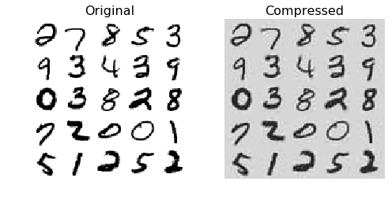

```python
import matplotlib
import matplotlib.pyplot as plt

def plot_digits(instances, images_per_row=5, **options):
    size = 28
    images_per_row = min(len(instances), images_per_row)
    images = [instance.reshape(size,size) for instance in instances]
    n_rows = (len(instances) - 1) // images_per_row + 1
    row_images = []
    n_empty = n_rows * images_per_row - len(instances)
    images.append(np.zeros((size, size * n_empty)))
    for row in range(n_rows):
        rimages = images[row * images_per_row : (row + 1) * images_per_row]
        row_images.append(np.concatenate(rimages, axis=1))
    image = np.concatenate(row_images, axis=0)
    plt.imshow(image, cmap = matplotlib.cm.binary, **options)
    plt.axis("off")

plt.figure(figsize=(7, 4))
plt.subplot(121)
plot_digits(X_mnist[::2100])
plt.title("Original", fontsize=16)
plt.subplot(122)
plot_digits(X_mnist_recovered[::2100])
plt.title("Compressed", fontsize=16)

save_fig("mnist_compression_plot")
plt.show()
```

## Incremental PCA

```python
# split MNIST into 100 minibatches using Numpy array_split()
# reduce MNIST down to 154 dimensions as before.
# note use of partial_fit() for each batch.

from sklearn.decomposition import IncrementalPCA

n_batches = 100
inc_pca = IncrementalPCA(n_components=154)

for X_batch in np.array_split(X_mnist, n_batches):
    print(".", end="")
    inc_pca.partial_fit(X_batch)

X_mnist_reduced_inc = inc_pca.transform(X_mnist)
```

```
....................................................................................................
```

## Randomised PCA

```python
rnd_pca = PCA(
    n_components=154,
    random_state=42,
    svd_solver="randomized")

X_reduced = rnd_pca.fit_transform(X_mnist)
```

### Performance comparison between the different PCAs.

```python
import time

for n_components in (2, 10, 154):
    print("n_components =", n_components)
    regular_pca = PCA(
        n_components=n_components)
    inc_pca     = IncrementalPCA(
        n_components=154,
        batch_size=500)
    rnd_pca     = PCA(
        n_components=154,
        random_state=42,
        svd_solver="randomized")

    for pca in (regular_pca, inc_pca, rnd_pca):
        t1 = time.time()
        pca.fit(X_mnist)
        t2 = time.time()
        print(pca.__class__.__name__, t2 - t1, "seconds")
```

```
n_components = 2
PCA 2.686570167541504 seconds
IncrementalPCA 42.3951210975647 seconds
PCA 10.239345788955688 seconds
n_components = 10
PCA 3.1540846824645996 seconds
IncrementalPCA 41.43201017379761 seconds
PCA 10.124917030334473 seconds
n_components = 154
PCA 8.976685047149658 seconds
IncrementalPCA 40.34954786300659 seconds
PCA 9.059792041778564 seconds
```

## Kernel PCA

```
Saving figure kernel_pca_plot
```

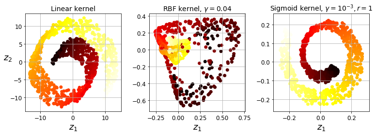

```python
# Below: Swiss roll reduced to 2D using 3 techniques:
# 1) linear kernel (equiv to PCA)
# 2) RBF kernel
# 3) sigmoid kernel (logistic)

from sklearn.datasets import make_swiss_roll
from sklearn.decomposition import KernelPCA

X, t = make_swiss_roll(
    n_samples=1000,
    noise=0.2,
    random_state=42)

lin_pca = KernelPCA(
    n_components = 2,
    kernel="linear",
    fit_inverse_transform=True)

rbf_pca = KernelPCA(
    n_components = 2,
    kernel="rbf",
    gamma=0.0433,
    fit_inverse_transform=True)

sig_pca = KernelPCA(
    n_components = 2,
    kernel="sigmoid",
    gamma=0.001,
    coef0=1,
    fit_inverse_transform=True)

y = t > 6.9

plt.figure(figsize=(11, 4))

for subplot, pca, title in (
    (131, lin_pca, "Linear kernel"),
    (132, rbf_pca, "RBF kernel, $\gamma=0.04$"),
    (133, sig_pca, "Sigmoid kernel, $\gamma=10^{-3}, r=1$")):

    X_reduced = pca.fit_transform(X)
    if subplot == 132:
        X_reduced_rbf = X_reduced

    plt.subplot(subplot)
    #plt.plot(X_reduced[y, 0], X_reduced[y, 1], "gs")
    #plt.plot(X_reduced[~y, 0], X_reduced[~y, 1], "y^")
    plt.title(title, fontsize=14)
    plt.scatter(X_reduced[:, 0], X_reduced[:, 1], c=t, cmap=plt.cm.hot)
    plt.xlabel("$z_1$", fontsize=18)
    if subplot == 131:
        plt.ylabel("$z_2$", fontsize=18, rotation=0)
    plt.grid(True)

save_fig("kernel_pca_plot")
plt.show()
```

## Selecting kernel and hyperparameters

### Using GridSearchCV

```python
from sklearn.model_selection import GridSearchCV
from sklearn.linear_model import LogisticRegression
from sklearn.pipeline import Pipeline

clf = Pipeline([
    ("kpca", KernelPCA(n_components=2)),
    ("log_reg", LogisticRegression())])

param_grid = [{
    "kpca__gamma": np.linspace(0.03, 0.05, 10),
    "kpca__kernel": ["rbf", "sigmoid"]}]

grid_search = GridSearchCV(clf, param_grid, cv=3)
grid_search.fit(X, y)

# best kernel & params?
print(grid_search.best_params_)
```

```
{'kpca__gamma': 0.043333333333333335, 'kpca__kernel': 'rbf'}
```

### Using minimisation of reconstruction error

```python
rbf_pca = KernelPCA(
    n_components = 2,
    kernel="rbf",
    gamma=0.0433,
    fit_inverse_transform=True) # perform reconstruction

X_reduced  = rbf_pca.fit_transform(X)
X_preimage = rbf_pca.inverse_transform(X_reduced)

# return reconstruction pre-image error
from sklearn.metrics import mean_squared_error
mean_squared_error(X, X_preimage)
```

```
32.786308795766125
```

## LLE

```
Saving figure lle_unrolling_plot
```

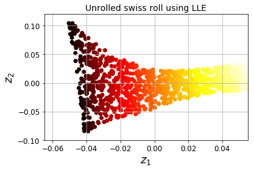

```python
# Use LLE to unroll a Swiss Roll.

from sklearn.manifold import LocallyLinearEmbedding

X, t = make_swiss_roll(
    n_samples=1000,
    noise=0.2,
    random_state=41)

lle = LocallyLinearEmbedding(
    n_neighbors=10,
    n_components=2,
    random_state=42)

X_reduced = lle.fit_transform(X)

plt.title("Unrolled swiss roll using LLE", fontsize=14)
plt.scatter(X_reduced[:, 0], X_reduced[:, 1], c=t, cmap=plt.cm.hot)
plt.xlabel("$z_1$", fontsize=18)
plt.ylabel("$z_2$", fontsize=18)
plt.axis([-0.065, 0.055, -0.1, 0.12])
plt.grid(True)

save_fig("lle_unrolling_plot")
plt.show()
```

## MDS, IsoMap, t-SNE, LDA

```python
from sklearn.manifold import MDS
mds = MDS(n_components=2, random_state=42)
X_reduced_mds = mds.fit_transform(X)
```

```python
from sklearn.manifold import Isomap
isomap = Isomap(n_components=2)
X_reduced_isomap = isomap.fit_transform(X)
```

```python
from sklearn.manifold import TSNE
tsne = TSNE(n_components=2)
X_reduced_tsne = tsne.fit_transform(X)
```

```python
from sklearn.discriminant_analysis import LinearDiscriminantAnalysis
lda = LinearDiscriminantAnalysis(n_components=2)
X_mnist = mnist["data"]
y_mnist = mnist["target"]
lda.fit(X_mnist, y_mnist)
X_reduced_lda = lda.transform(X_mnist)
```

```
Saving figure other_dim_reduction_plot
```

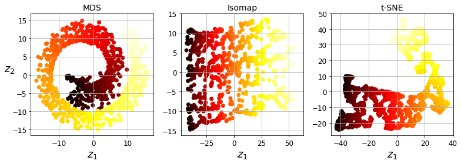

```python
titles = ["MDS", "Isomap", "t-SNE"]

plt.figure(figsize=(11,4))

for subplot, title, X_reduced in zip((131, 132, 133), titles,
                                     (X_reduced_mds, X_reduced_isomap, X_reduced_tsne)):
    plt.subplot(subplot)
    plt.title(title, fontsize=14)
    plt.scatter(X_reduced[:, 0], X_reduced[:, 1], c=t, cmap=plt.cm.hot)
    plt.xlabel("$z_1$", fontsize=18)
    if subplot == 131:
        plt.ylabel("$z_2$", fontsize=18, rotation=0)
    plt.grid(True)

save_fig("other_dim_reduction_plot")
plt.show()
```